# STA 141A Note - Statistical Learning and Linear Regression

Li Yuan

5/1/2022

# I. Statistical Learning

Statistical learning refers to a vast set of tools for understanding data.

These tools can be classified as supervised or unsupervised.

## 1. Supervised Statistical Learning

Supervised statistical learning involves building a statistical model for predicting, or estimating, an output based on one or more inputs.

Suppose that we observe a quantitative response $Y$ and $p$ different predictors, $X_1, X_2,..., X_p$.

We assume that there is some relationship between $Y$ and $X = (X_1, X_2,..., X_p)$, which can be written in the very general form:

$$Y=f(X)+\epsilon.$$

Here $f$ is some fixed but unknown function of $X_1, X_2,..., X_p$, and $\epsilon$ is a random error term, which is independent of $X$ and has mean zero. In this formulation, $f$ represents the systematic information that $X$ provides about $Y$.

In essence, statistical learning refers to a set of approaches for estimating $f$.

**Why estimate $f$?**

**Prediction**. We can predict $Y$ using:

$$\hat{Y}=\hat{f}(X),$$

where $\hat{f}$ represents our estimate for $f$, and $\hat{Y}$ represents the resulting prediction for $Y$.

**Inference**. We are often interested in understanding the way that $Y$ is affected as $X1,...,Xp$ change. In this situation we wish to estimate $f$, but our goal is not necessarily to make predictions for $Y$.

**Parametric Methods**. Parametric methods involve a two-step model-based approach.

**(a)** First, we make an assumption about the functional form, or shape, of $f$. For example, one very simple assumption is that $f$ is linear in $X$:

$$f(X) = \beta_0+\beta_1X_1+\beta_2X_2+...+\beta_pX_p.$$

This is a linear model. The problem of estimating $f$ is greatly simplifed. Instead of having to estimate an entirely arbitrary p-dimensional function $f(X)$, one only needs to estimate the $p+1$ coefficients $\beta_0, \beta_1,...,\beta_p$.

**(b)** After a model has been selected, we need a procedure that uses the training data to fit or train the model. In the case of the linear model, we need to estimate the parameters $\beta_0, \beta_1,...,\beta_p$.

**Non-parametric methods**

Non-parametric methods do not make explicit assumptions about the functional form of $f$.

## 2. Unsupervised Statistical Learning

With unsupervised statistical learning, there are inputs but no supervising output; nevertheless we can learn relationships and structure from such data.

The unsupervised learning describes a situation in which we have only a set of features $X1, X2,..., Xp$ measured on n observations.

The goal is to discover interesting things about the measurements on $X_1, X_2,..., X_p$.

Unsupervised learning is often performed as part of an exploratory data analysis.

Two of the main methods used in unsupervised learning are principal component (PCA) and cluster analysis.

**Example 1:** The goal is to discover interesting things about the measurements on $X_1, X_2,..., X_p$.

It might be of interest to look for subgroups among the breast cancer samples, or among the genes, in order to obtain a better understanding of the disease.

**Example 2:** An online shopping site might try to identify groups of shoppers with similar browsing and purchase histories, as well as items that are of particular interest to the shoppers within each group.

Then an individual shopper can be preferentially shown the items in which he or she is particularly likely to be interested, based on the purchase histories of similar shoppers.

Unsupervised learning is often much more challenging since there is no simple goal for the analysis, such as prediction of a response.

If we fit a predictive model using a supervised learning technique, then it is possible to check our work by seeing how well our model predicts the response $Y$ on observations not used in fitting the model.

However, in unsupervised learning, there is no way to check our work because we don’t know the true answer - the problem is unsupervised.

# II. Linear Regression

## 1. Motivation

Linear regression is a tool for predicting a quantitative response.

## 2. Multiple Linear Regression

Assume that $y = X\beta+\epsilon$ or
$$\left[ {\begin{array}{cc}
y_1 \\
y_2 \\
\vdots \\
y_n \\
\end{array} } \right]=\left[ {\begin{array}{cccc}
1&x_{11}&...&x_{1p}\\
1&x_{21}&...&x_{2p}\\
\vdots&\vdots&\ddots&\vdots\\
1&x_{n1}&...&x_{np} \\
\end{array} } \right] \left[ {\begin{array}{cc}
\beta_0 \\
\beta_1 \\
\vdots \\
\beta_p \\
\end{array} } \right]+\left[ {\begin{array}{cc}
\epsilon_1 \\
\epsilon_2 \\
\vdots \\
\epsilon_n \\
\end{array} } \right]$$

$X$ is assumed to be deterministic.

**Example:** Adtertising data set

The Advertising data set consists of the sales of a product in 200 different markets, along with advertising budgets for the product in each of those markets for three different media: `TV`, `radio`, and `newspaper`.

In this setting, the advertising budgets are input variables while sales is an output variable.

First 6 rows of the Adtertising data set

| X | TV | Radio | Newspaper | Sales |
| --- | --- | --- | --- | --- |
| 1 | 230.1 | 37.8 | 69.2 | 22.1 |
| 2 | 44.5 | 39.3 | 45.1 | 10.4 |
| 3 | 17.2 | 45.9 | 69.3 | 9.3 |
| 4 | 151.5 | 41.3 | 58.5 | 18.5 |
| 5 | 180.8 | 10.8 | 58.4 | 12.9 |
| 6 | 8.7 | 48.9 | 75.0 | 7.2 |

**Question (1)**: Is there a relationship between advertising budget and sales?

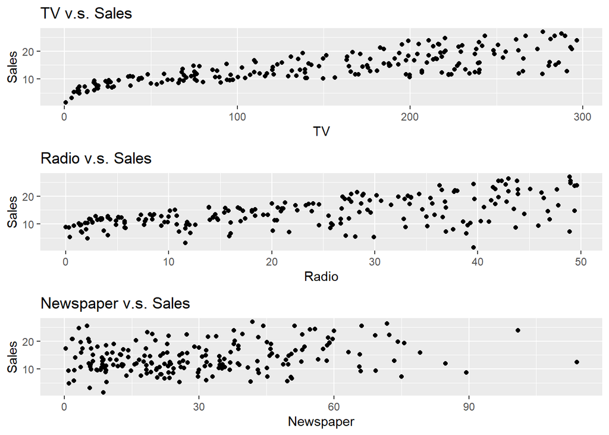

```r
tv_sp = qplot(x = TV, y = Sales, data = Advertising,
              main = "TV v.s. Sales")
radio_sp = qplot(x = Radio, y = Sales, data = Advertising,
                 main = "Radio v.s. Sales")
newspaper_sp = qplot(x = Newspaper, y = Sales, data = Advertising,
                     main = "Newspaper v.s. Sales")
gridExtra::grid.arrange(tv_sp,
                        radio_sp,
                        newspaper_sp, ncol=1)
```

Seems there are some relationships between budgets and sales.

**Question (2)**: How strong is the relationship between advertising budget and sales?

```r
attach(Advertising)
cor(Sales, TV)
```

```
## [1] 0.7822244
```

```r
cor(Sales, Radio)
```

```
## [1] 0.5762226
```

```r
cor(Sales, Newspaper)
```

```
## [1] 0.228299
```

```r
kable(cor(Advertising[,-1]), caption = "Relationships between budgets and sales")
```

Relationships between budgets and sales

|  | TV | Radio | Newspaper | Sales |
| --- | --- | --- | --- | --- |
| TV | 1.0000000 | 0.0548087 | 0.0566479 | 0.7822244 |
| Radio | 0.0548087 | 1.0000000 | 0.3541038 | 0.5762226 |
| Newspaper | 0.0566479 | 0.3541038 | 1.0000000 | 0.2282990 |
| Sales | 0.7822244 | 0.5762226 | 0.2282990 | 1.0000000 |

We can see the relationship between TV and Sales are the strongests.

**Question (3)**: Which media contribute to sales?

```r
lm(Sales ~ TV + Radio + Newspaper)
```

```
##
## Call:
## lm(formula = Sales ~ TV + Radio + Newspaper)
##
## Coefficients:
## (Intercept)           TV        Radio    Newspaper
##    2.938889     0.045765     0.188530    -0.001037
```

```r
lreg <- lm(Sales ~ TV + Radio + Newspaper)
class(lreg)
```

```
## [1] "lm"
```

```r
summary(lreg)
```

```
##
## Call:
## lm(formula = Sales ~ TV + Radio + Newspaper)
##
## Residuals:
##     Min      1Q  Median      3Q     Max
## -8.8277 -0.8908  0.2418  1.1893  2.8292
##
## Coefficients:
##              Estimate Std. Error t value Pr(>|t|)
## (Intercept)  2.938889   0.311908   9.422   <2e-16 ***
## TV           0.045765   0.001395  32.809   <2e-16 ***
## Radio        0.188530   0.008611  21.893   <2e-16 ***
## Newspaper   -0.001037   0.005871  -0.177     0.86
## ---
## Signif. codes:  0 '***' 0.001 '**' 0.01 '*' 0.05 '.' 0.1 ' ' 1
##
## Residual standard error: 1.686 on 196 degrees of freedom
## Multiple R-squared:  0.8972, Adjusted R-squared:  0.8956
## F-statistic: 570.3 on 3 and 196 DF,  p-value: < 2.2e-16
```

From the p-values we can see that Newspaper may not contribute a lot to the sales.

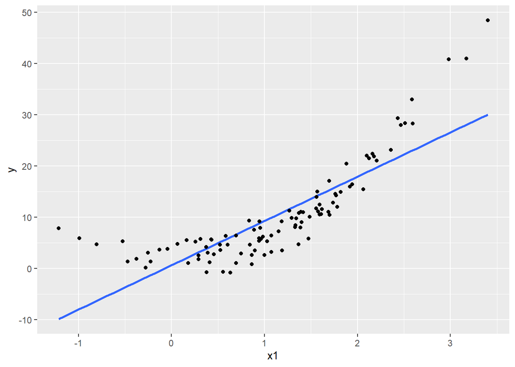

```r
# residual plots
library(ggplot2)
set.seed(1)
x1 <- rnorm(100, 1, 1)
x2 <- rnorm(100, 0, 1)
y <- 2+4*x1^2-2*x2+rnorm(100, 0, 1)
df_sample <- data.frame(y = y, x1=x1, x2=x2)
ggplot(data = df_sample, mapping = aes(x = x1, y = y)) +
  geom_smooth(se = FALSE, method = "lm") +
  geom_point()
```

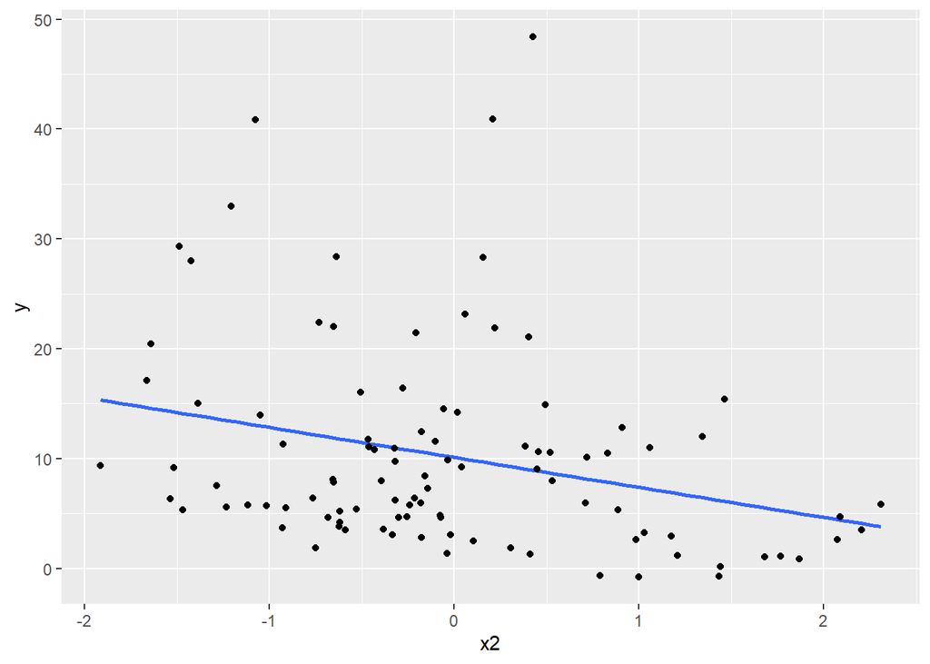

```r
ggplot(data = df_sample, mapping = aes(x = x2, y = y)) +
  geom_smooth(se = FALSE, method = "lm") +
  geom_point()
```

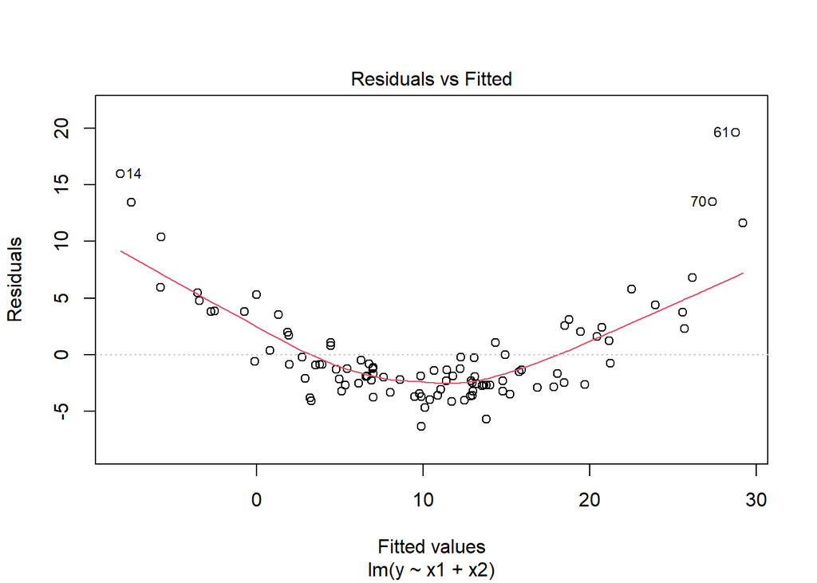

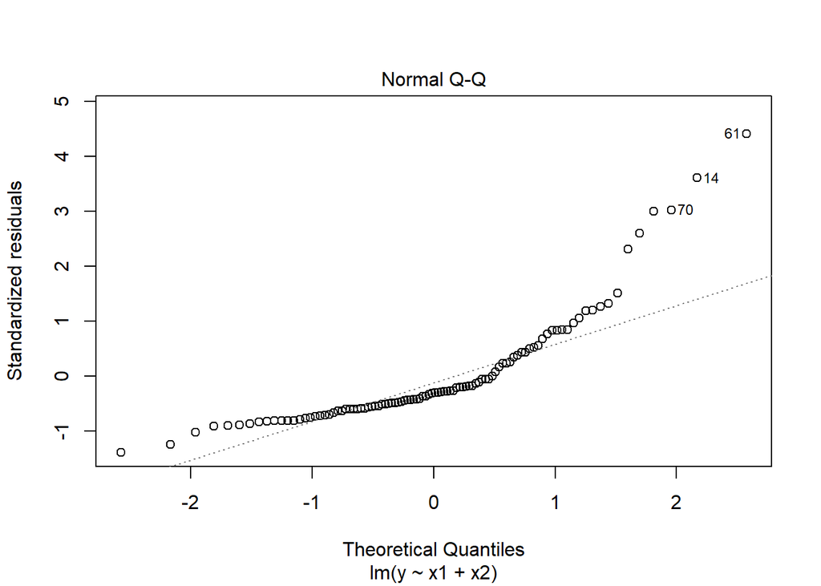

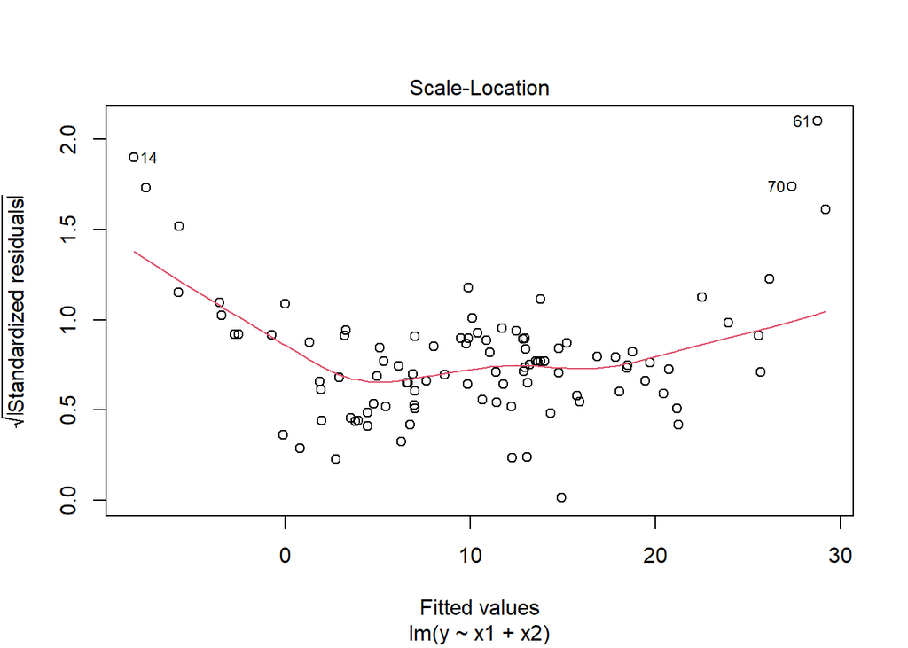

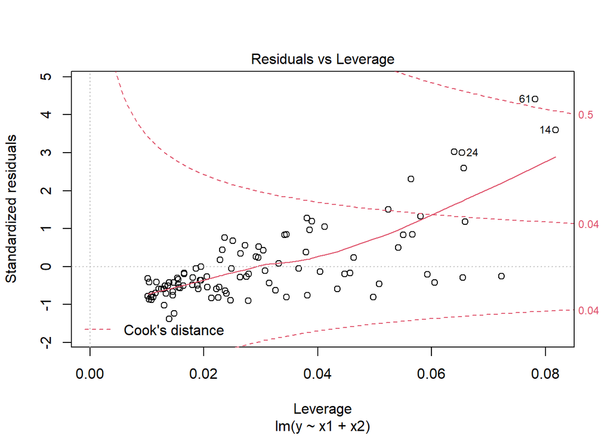

```r
par(mfrow=c(1,1))
res <- lm(y ~ x1+x2, df_sample)
plot(res, cook.levels = c(4/100, 0.5))
```

```r
summary(res)
```

```
##
## Call:
## lm(formula = y ~ x1 + x2, data = df_sample)
##
## Residuals:
##    Min     1Q Median     3Q    Max
## -6.383 -2.724 -1.407  1.626 19.633
##
## Coefficients:
##             Estimate Std. Error t value Pr(>|t|)
## (Intercept)   0.5423     0.7390   0.734    0.465
## x1            8.6333     0.5187  16.644  < 2e-16 ***
## x2           -2.7224     0.4864  -5.597 2.02e-07 ***
## ---
## Signif. codes:  0 '***' 0.001 '**' 0.01 '*' 0.05 '.' 0.1 ' ' 1
##
## Residual standard error: 4.636 on 97 degrees of freedom
## Multiple R-squared:  0.7608, Adjusted R-squared:  0.7559
## F-statistic: 154.3 on 2 and 97 DF,  p-value: < 2.2e-16
```

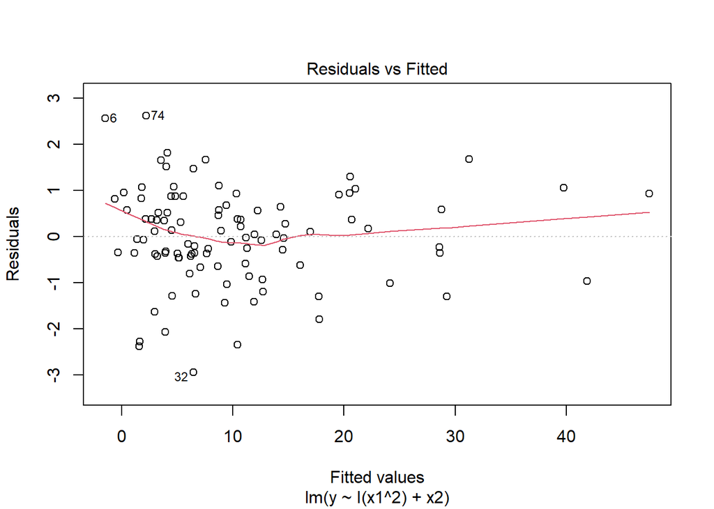

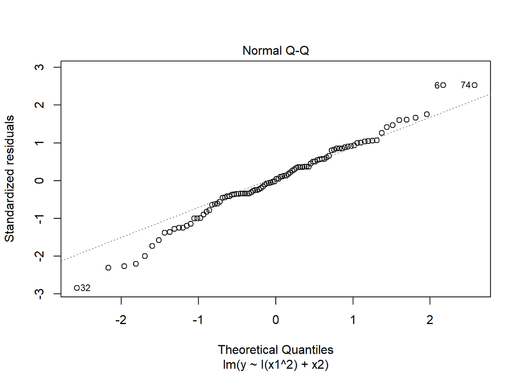

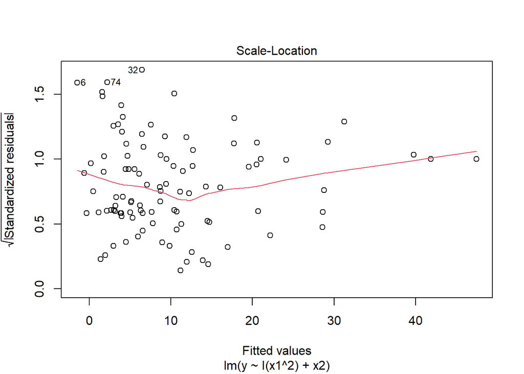

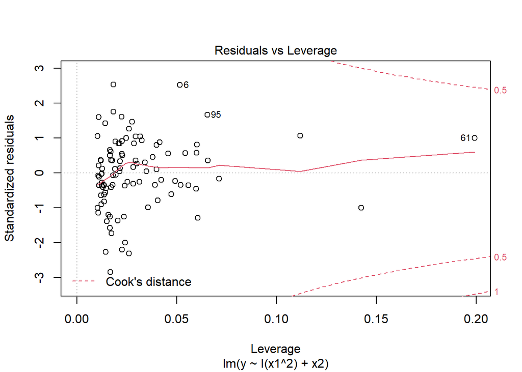

```r
# adding a non-linear transformation
res <- lm(y ~ I(x1^2)+x2, df_sample)
plot(res)
```

```r
summary(res)
```

```
##
## Call:
## lm(formula = y ~ I(x1^2) + x2, data = df_sample)
##
## Residuals:
##      Min       1Q   Median       3Q      Max
## -2.94647 -0.46122  0.01174  0.64885  2.61986
##
## Coefficients:
##             Estimate Std. Error t value Pr(>|t|)
## (Intercept)  2.02519    0.14105   14.36   <2e-16 ***
## I(x1^2)      4.00122    0.04688   85.34   <2e-16 ***
## x2          -2.05328    0.10978  -18.70   <2e-16 ***
## ---
## Signif. codes:  0 '***' 0.001 '**' 0.01 '*' 0.05 '.' 0.1 ' ' 1
##
## Residual standard error: 1.044 on 97 degrees of freedom
## Multiple R-squared:  0.9879, Adjusted R-squared:  0.9876
## F-statistic:  3952 on 2 and 97 DF,  p-value: < 2.2e-16
```

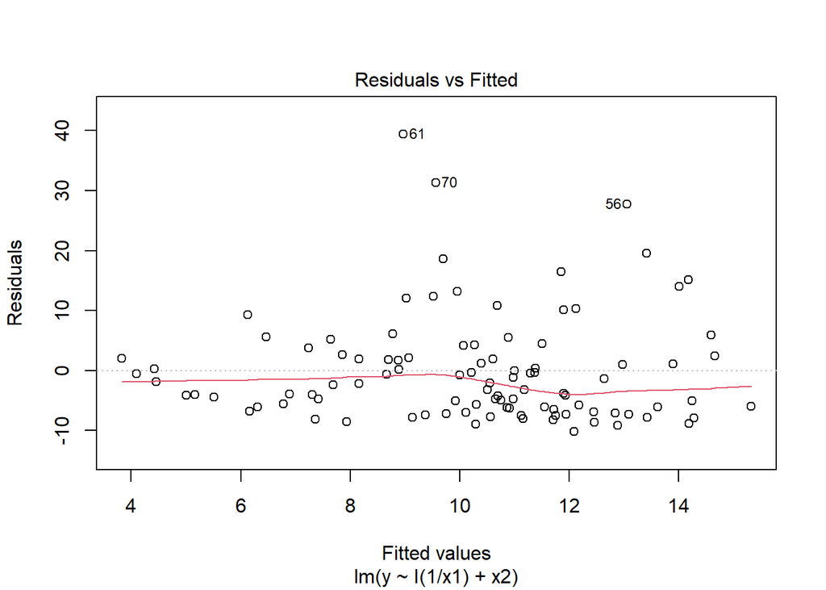

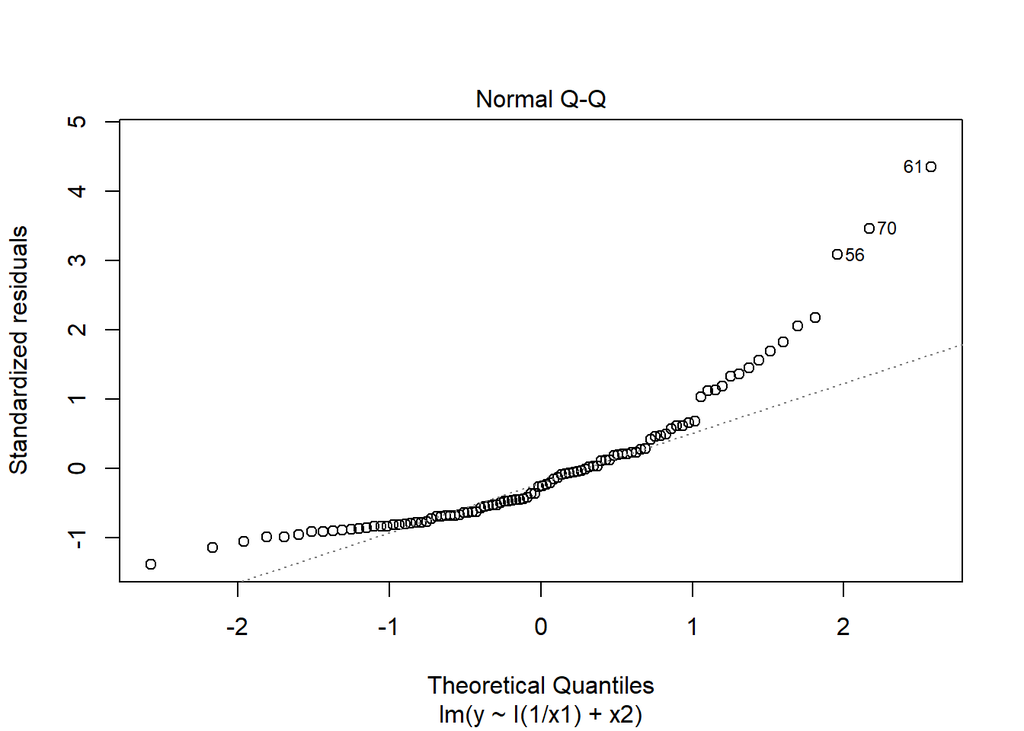

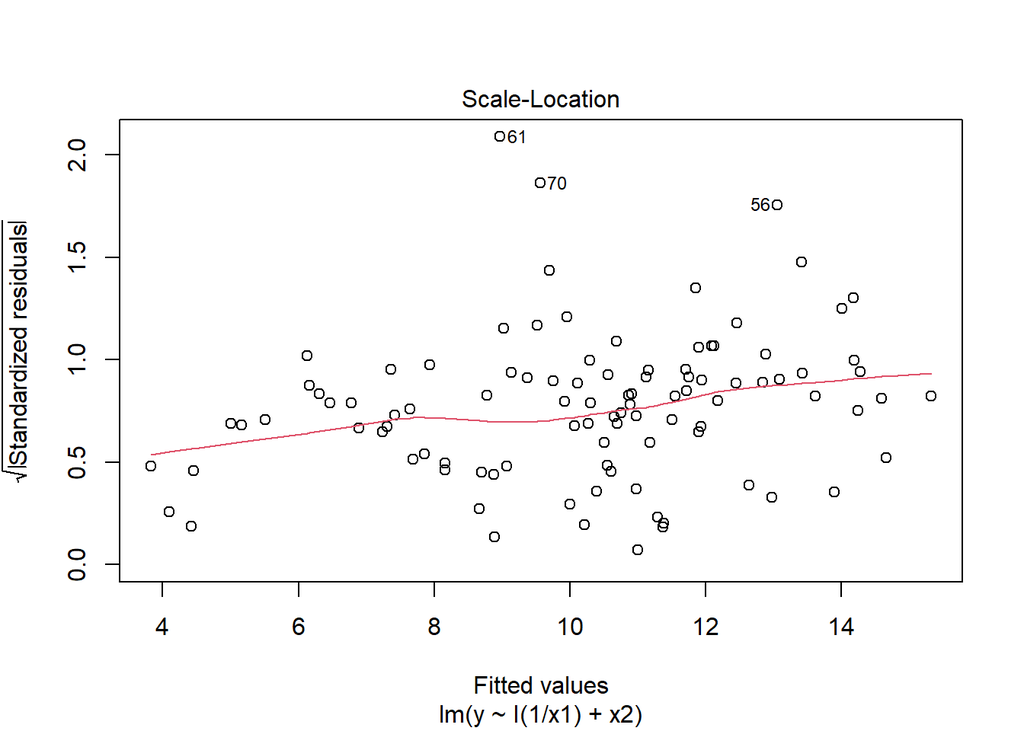

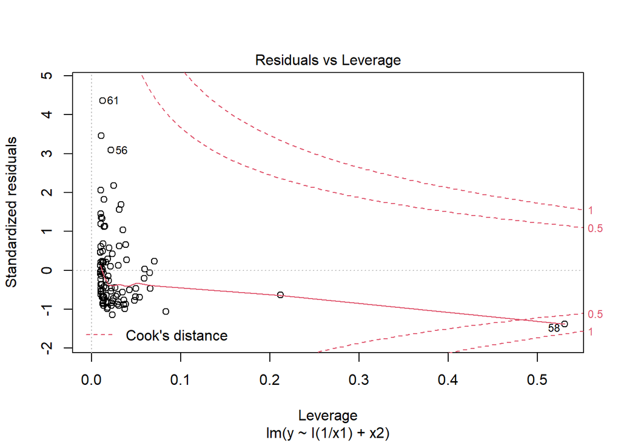

```r
# adding a less useful non-linear transformation
res <- lm(y ~ I(1/x1)+x2, df_sample)
plot(res)
```

```r
summary(res)
```

```
##
## Call:
## lm(formula = y ~ I(1/x1) + x2, data = df_sample)
##
## Residuals:
##     Min      1Q  Median      3Q     Max
## -10.241  -6.208  -2.301   2.468  39.417
##
## Coefficients:
##             Estimate Std. Error t value Pr(>|t|)
## (Intercept) 10.13431    0.93076  10.888  < 2e-16 ***
## I(1/x1)     -0.02797    0.28189  -0.099  0.92117
## x2          -2.72510    0.95657  -2.849  0.00536 **
## ---
## Signif. codes:  0 '***' 0.001 '**' 0.01 '*' 0.05 '.' 0.1 ' ' 1
##
## Residual standard error: 9.102 on 97 degrees of freedom
## Multiple R-squared:  0.0778, Adjusted R-squared:  0.05879
## F-statistic: 4.092 on 2 and 97 DF,  p-value: 0.01968
```

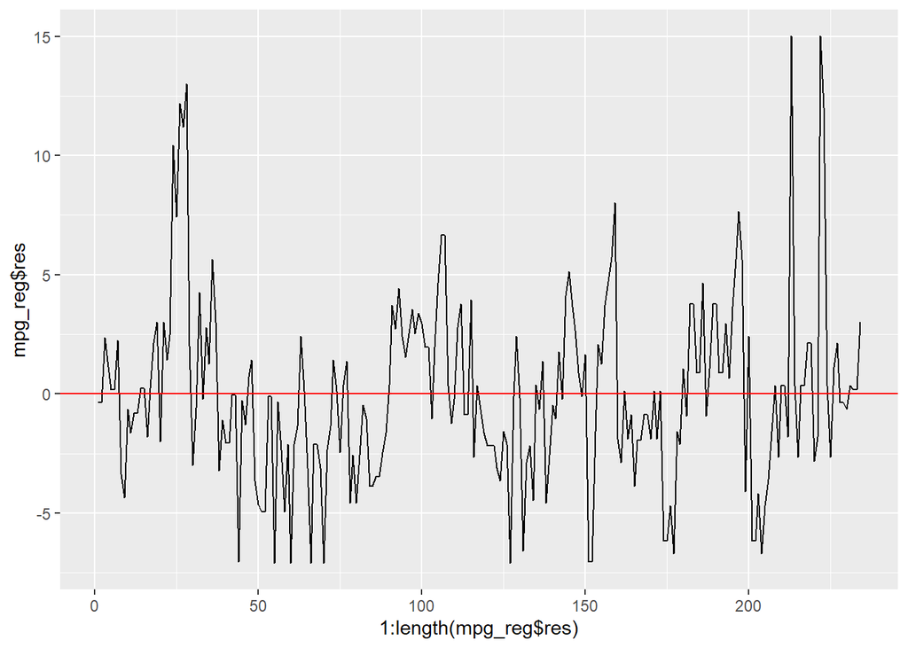

```r
# uncorrelated errors
data(mpg)
mpg_reg <- lm(hwy ~ displ, mpg)

qplot(1:length(mpg_reg$res),mpg_reg$res,geom="line") +
    geom_hline(yintercept = 0, colour = "red")
```

```r
# The LjungâBox test (https://en.wikipedia.org/wiki/LjungâBox_test)
Box.test(mpg_reg$res)
```

```
##
##  Box-Pierce test
##
## data:  mpg_reg$res
## X-squared = 63.728, df = 1, p-value = 1.443e-15
```

```r
# null hypothesis of independence
# The Durbin-Watson test (https://en.wikipedia.org/wiki/DurbinâWatson_statistic)
library(car)
dwt(mpg_reg)
```

```
##  lag Autocorrelation D-W Statistic p-value
##    1        0.521862     0.9535833       0
##  Alternative hypothesis: rho != 0
```

```r
#
mpg_reg2 <- lm(hwy ~ ., data = mpg)
Box.test(mpg_reg2$res)
```

```
##
##  Box-Pierce test
##
## data:  mpg_reg2$res
## X-squared = 1.5019, df = 1, p-value = 0.2204
```

```r
dwt(mpg_reg2)
```

```
##  lag Autocorrelation D-W Statistic p-value
##    1     -0.08011445      2.152437    0.13
##  Alternative hypothesis: rho != 0
```

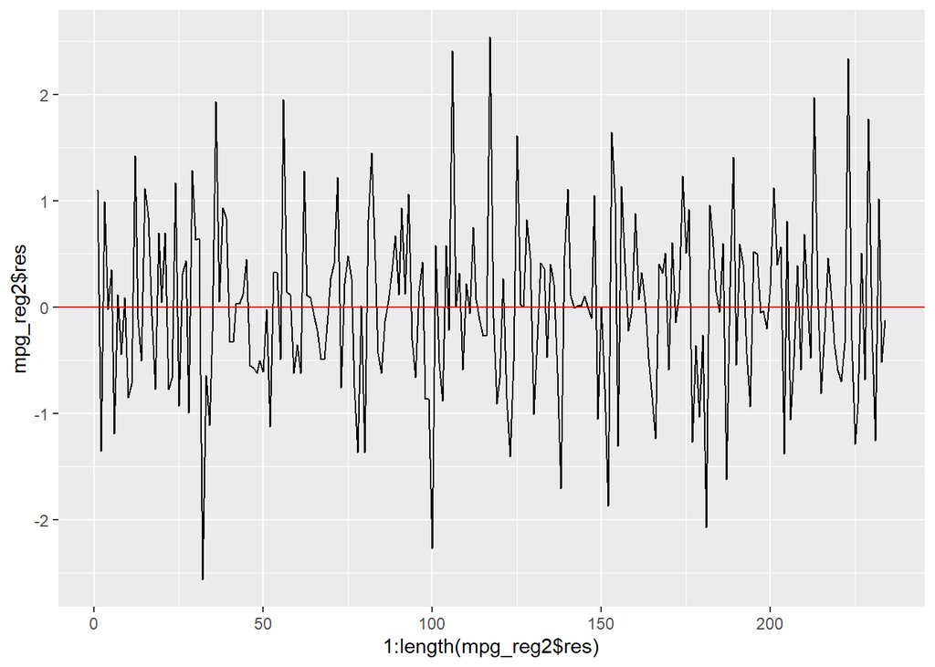

```r
qplot(1:length(mpg_reg2$res),mpg_reg2$res,geom="line") +
  geom_hline(yintercept = 0, colour = "red")
```

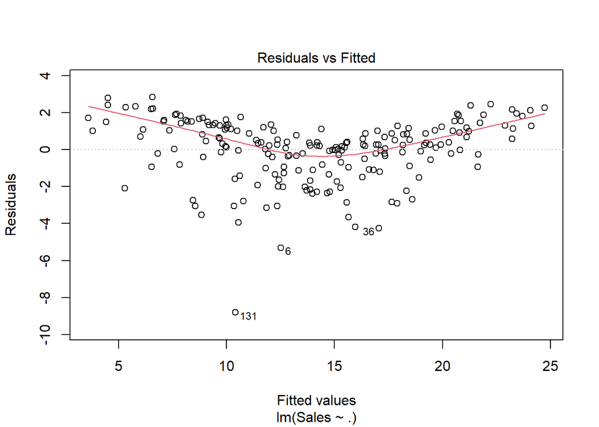

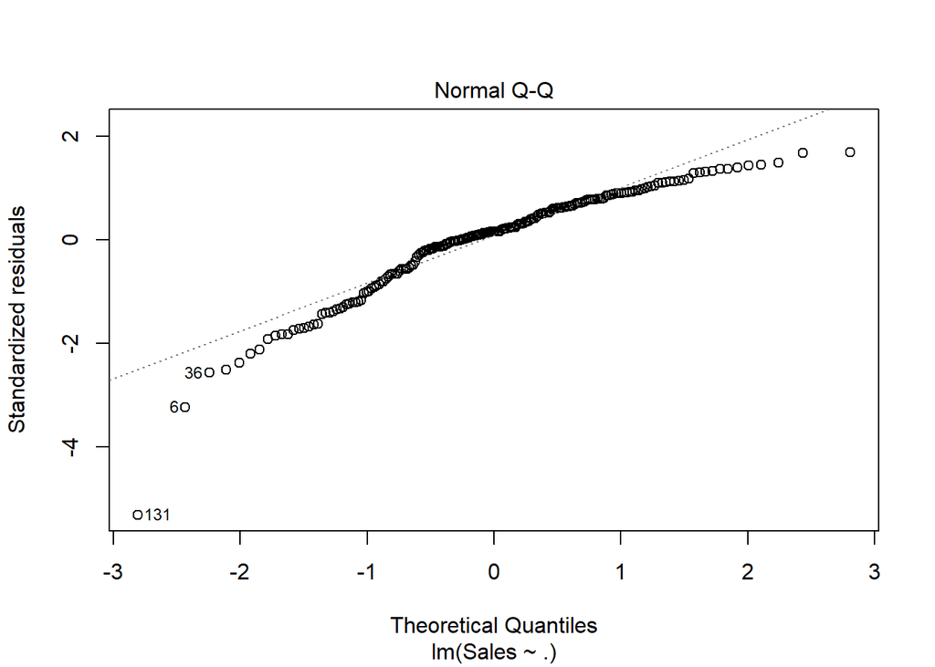

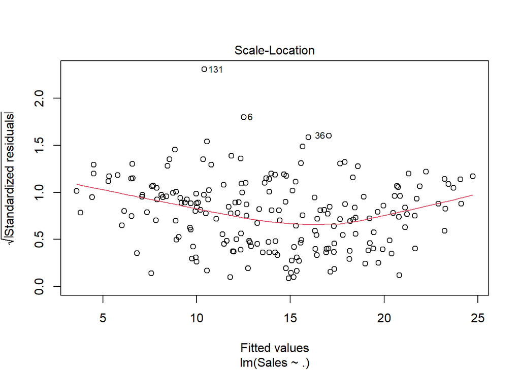

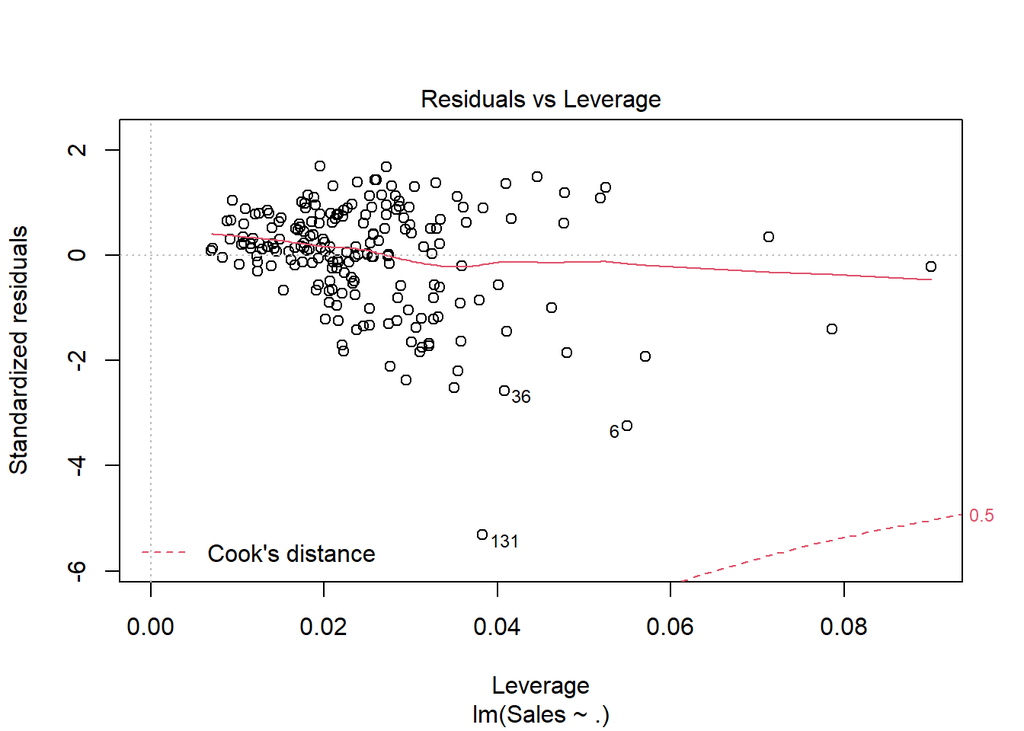

```r
# homoskedasticity
# par(mfrow = c(2,2))
Advertising <- read.csv('Advertising.csv')
sales_reg <- lm(Sales ~ ., data = Advertising)
plot(sales_reg)
```

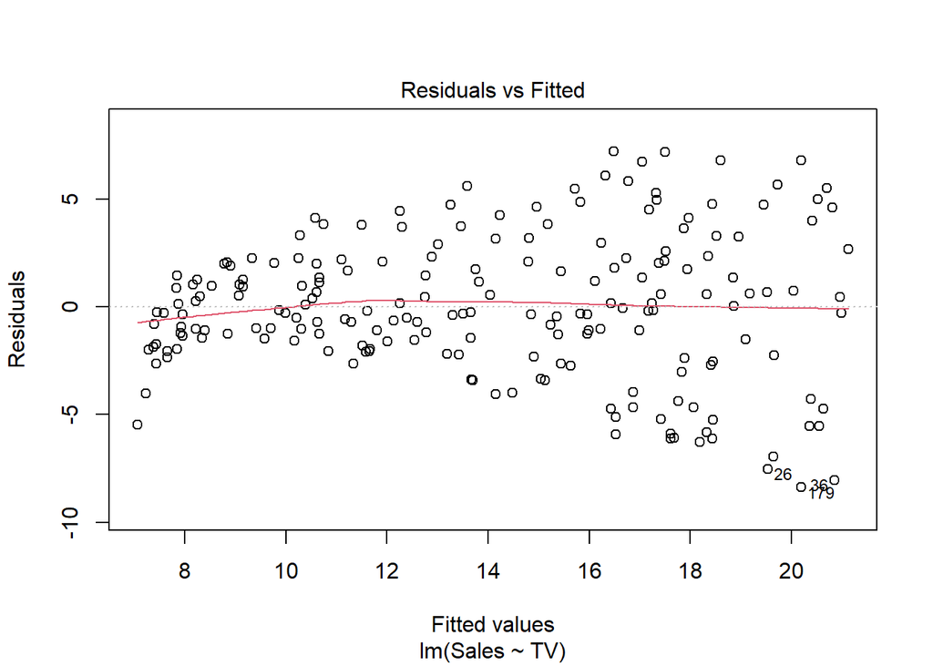

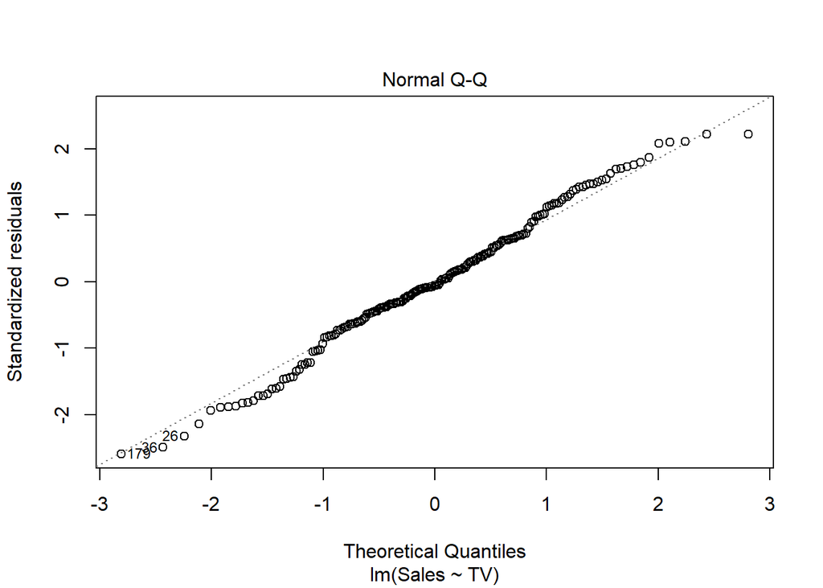

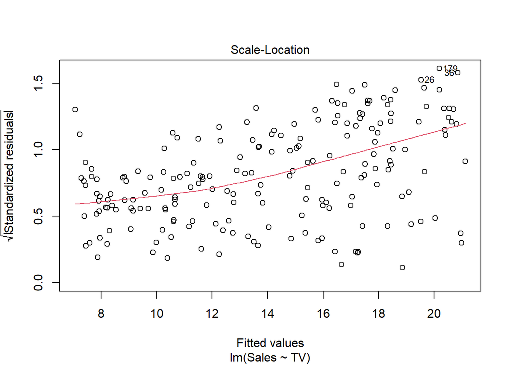

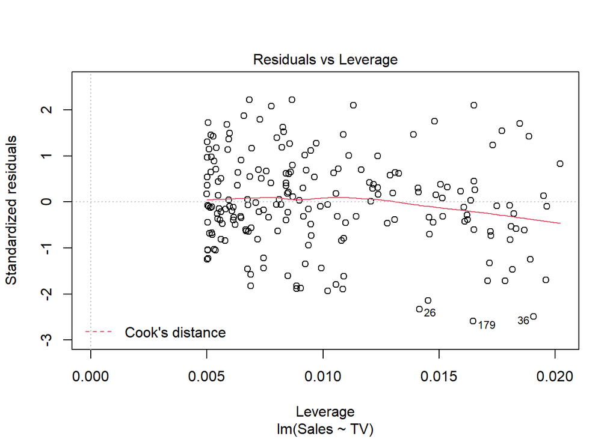

```r
sales_reg1 <- lm(Sales ~ TV, data = Advertising)
plot(sales_reg1)
```

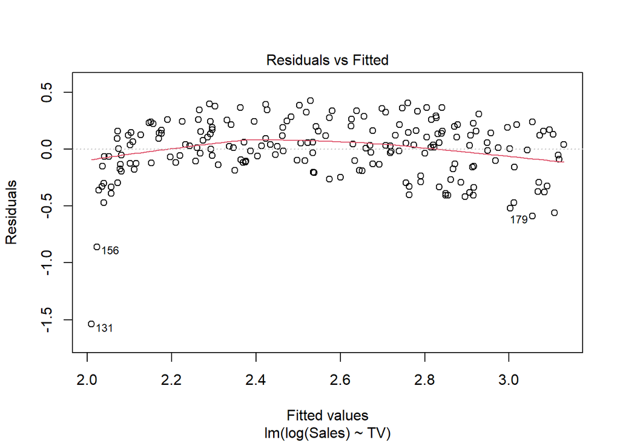

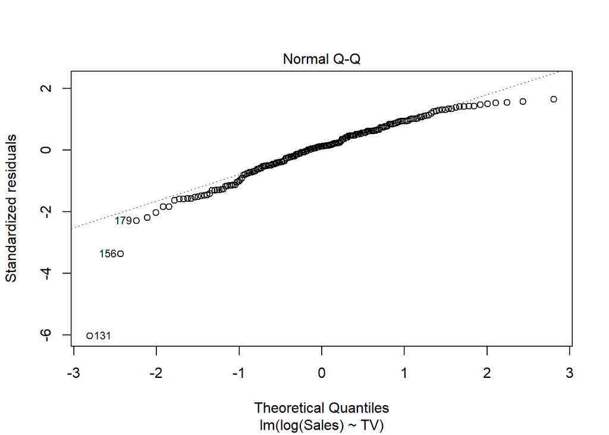

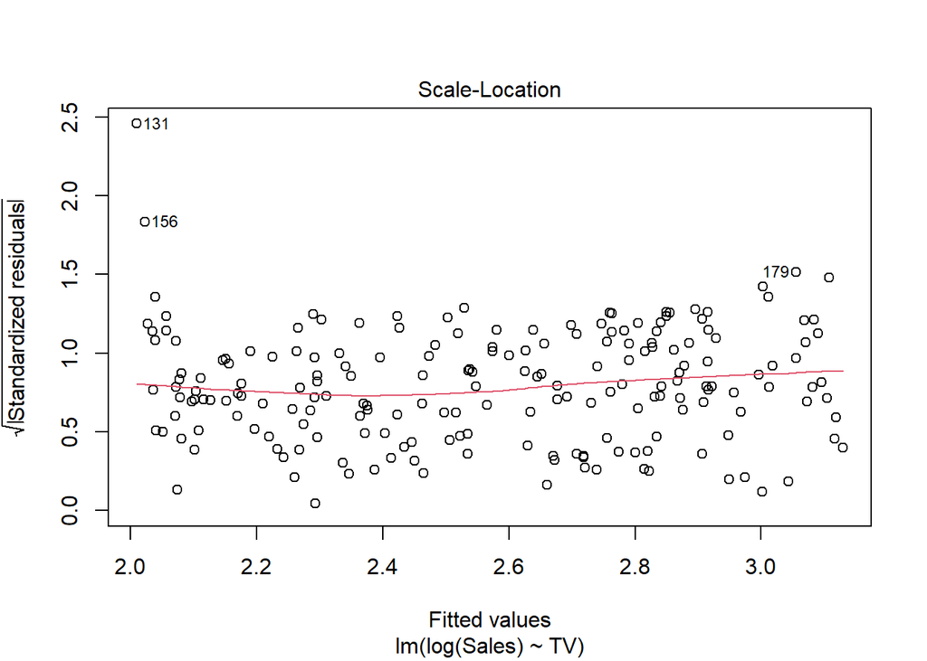

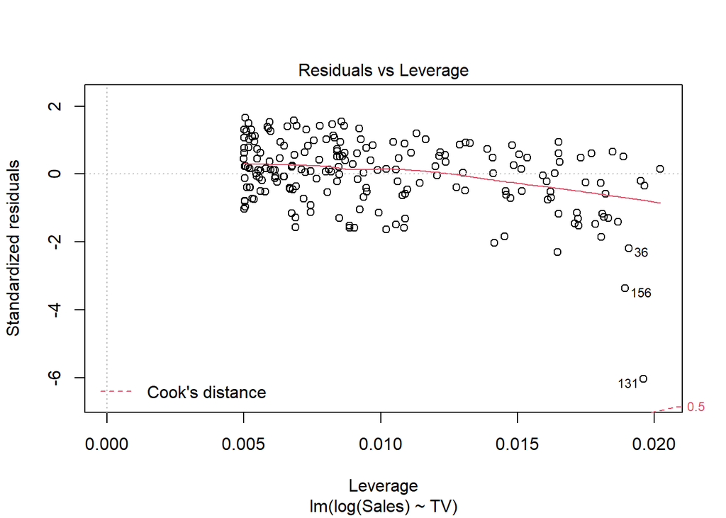

```r
sales_reg1_tr <- lm(log(Sales) ~ TV, data = Advertising)
plot(sales_reg1_tr)
```

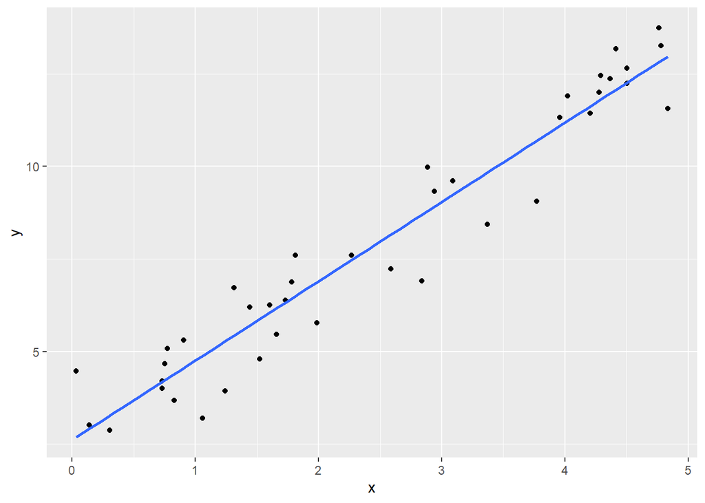

```r
# outliers and leverage
b0 <- 3;b1 <- 2; sigma2 <- 1
n <- 40;p <- 1
x <- runif(n,0,5)
y <- b0+b1*x+rnorm(n,0,sqrt(sigma2))
df_sample <- data.frame(x = x, y = y)
df_sample1 <- rbind(df_sample,c(2.5,18))
df_sample2 <- rbind(df_sample,c(6,25))

# recall: the intercept (b_0) is the mean of y when x=0 and
# the b_1 represents the slope
ggplot(data = df_sample, mapping = aes(x = x, y = y),) +
    geom_point() +
    geom_smooth(method = "lm", se = FALSE)
```